# Clase 4 - Introducción a Python

```python
#Configuraciones de Python
import pandas as pd
pd.options.display.max_rows = 10
```

[figure not shown]

```python
from IPython.display import Image
Image(filename='./logo_python.png')
```

## Diagramas de Clases UML

Los diagramas de clases UML nos muestran una representación de un conjunto de clases, sus atributos, métodos y sus relaciones.

Este tipo de diagramas son muy utilizados a la hora de programar para representar la estructura de clases de un programa o una porción de un programa.

**Las clases**

La representación de las clases de hacen de la siguiente manera:

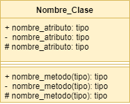

```python
from IPython.display import Image
Image(filename='./clase.png')
```

Como se puede apreciar en la imagen las clases poseen 3 cuadros:

- El primero con el nombre de la clase
- El segundo con los atributos de la clase.
  - Cada atributo va precedido por un signo `+` (si el atributo es público), `-`(si el atributo es privado) o `#` (si el atributo es protegido).
  - Después del nombre de cada atributo se coloca el tipo el cual debería ser el atributo. (Para hacernos una idea de como tratarlo).
- El tercero muestra los métodos de la clase.
  - Cada método va precedido por un signo `+` (si el método es público), `-`(si el método es privado) o `#` (si el método es protegido).
  - Después del nombre de cada método se coloca entre paréntesis el tipo de los parámetros del método (en caso de tener parámetros).
  - Al final cada método se coloca el tipo de lo que retorna el método.

Nota: En los métodos no es necesario poner funciones como gets y sets, ya que se entiende que se crean.

**Relación de Herencia**

La herencia en un diagrama de clases se representa con un flecha, donde la flecha apunta a la clase base.

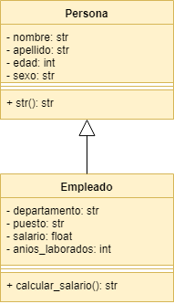

```python
from IPython.display import Image
Image(filename='./herencia.png')
```

```python
class Persona:
    def __init__(self, nombre, apellido, edad, sexo):
        self.__nombre = nombre
        self.__apellido = apellido
        self.__edad = edad
        self.__sexo = sexo
    def __str__(self):
        x = "%s %s [edad: %i sexo: %s]"
        x = x % (self.__nombre, self.__apellido, self.__edad, self.__sexo)
        return(x)

class Empleado(Persona):
    def __init__(self, nombre, apellido, edad, sexo,
                 departamento, puesto, salario, anios_laborados):
        super().__init__(nombre, apellido, edad, sexo)
        self.__departamento = departamento
        self.__puesto = puesto
        self.__salario = salario
        self.__anios_laborados = anios_laborados
    def calcular_salario(self):
        return( self.__salario + 5000 * self.__anios_laborados )
    def __str__(self):
        x = "%s\n%s - %s [salario: %f años: %i]"
        x = x % (super().__str__(), self.__departamento, self.__puesto, self.calcular_salario(), self.__anios_laborados)
        return(x)
```

Note que en la clase `Empleado` no se tuvo que volver a poner todos los atributos y métodos de `Persona` ya que se entiende que se heredan.

**Relación de Agregación**

La agregación representan la relación entre una entidad contenedora y sus partes, en la cual las partes no son dependientes de la entidad contenedora.

Esta relación se pone con una línea con un rombo vacío en la clase contenedora:

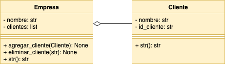

```python
from IPython.display import Image
Image(filename='./agregacion.png')
```

```python
class Empresa:
    def __init__(self, nombre):
        self.__nombre = nombre
        self.__clientes = []
    def agregar_cliente(self, nuevo_cliente):
        self.__clientes.append(nuevo_cliente)
    def eliminar_cliente(self, id_cliente):
        for i in range(len(self.__clientes)):
            if id_cliente == self.__clientes[i].id_cliente:
                del self.__clientes[i]
    def __str__(self):
        x = "Empresa: "+self.__nombre+"\nClientes:\n"
        for cliente in self.__clientes:
            x = x + "\n" + str(cliente)
        return(x)

class Cliente:
    def __init__(self, nombre, id_cliente):
        self.__nombre = nombre
        self.__id_cliente = id_cliente
    @property
    def id_cliente(self):
        return(self.__id_cliente)
    def __str__(self):
        x = "%s (ID:%s)" % (self.__nombre, self.__id_cliente)
        return(x)
```

```python
x = Empresa("Comida")
c1 = Cliente("Juan", "12554")
c2 = Cliente("Pedro", "5454ASDF")
c3 = Cliente("Luis", "AA8564d5")
x.agregar_cliente(c1)
x.agregar_cliente(c2)
x.agregar_cliente(c3)
print(x)
del x
print(c1)
```

```
Empresa: Comida
Clientes:

Juan (ID:12554)
Pedro (ID:5454ASDF)
Luis (ID:AA8564d5)
Juan (ID:12554)
```

En este caso la entidad contenedora (también conocida como "todo") es Empresa la cual contiene "Clientes" (Las partes) y se dice las partes son independientes del todo ya que si destruimos el objeto Empresa no tiene sentido que destruyamos a los clientes que contienen ya que estos pueden estar en otras empresas.

**Relación de Composición**

La composición son muy parecidas a las de agregación, ya que la composición también se entre una entidad contenedora y sus partes, pero para la composición las partes si son dependientes de la entidad contenedora.

Por lo que si eliminamos el todo se eliminan también sus partes.

Esta relación se pone con una línea con un rombo relleno en la clase contenedora:

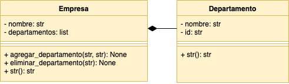

```python
from IPython.display import Image
Image(filename='./composicion.png')
```

```python
class Empresa:
    def __init__(self, nombre):
        self.__nombre = nombre
        self.__departamentos = []
        self.agregar_departamento("Administrativo", "ADMI-001")
    def agregar_departamento(self, nombre, id_departamento):
        nuevo = Departamento(nombre, id_departamento)
        self.__departamentos.append(nuevo)
    def eliminar_departamento(self, id_departamento):
        for i in range(len(self.departamentos)):
            if id_departamento == self.__departamentos[i].id:
                del self.__departamentos[i]
    def __str__(self):
        x = "Empresa: "+self.__nombre+"\nDepartamentos:\n"
        for departamento in self.__departamentos:
            x = x + "\n" + str(departamento)
        return(x)

class Departamento:
    def __init__(self, nombre, id_departamento):
        self.__nombre = nombre
        self.__id = id_departamento
    @property
    def id(self):
        return(self.__id)
    def __str__(self):
        x = "%s (ID:%s)" % (self.__nombre, self.__id)
        return(x)
```

```python
x = Empresa("Comida")
x.agregar_departamento("Informatica", "INFO-001")
x.agregar_departamento("Comunicaciones", "COM-001")
print(x)
```

```
Empresa: Comida
Departamentos:

Administrativo (ID:ADMI-001)
Informatica (ID:INFO-001)
Comunicaciones (ID:COM-001)
```

**Cardinalidad**

Es un indicador que representa cuantos objetos de cada clase intervienen en la relación.

Aplica para relaciones de agregación y de composición.

Por ejemplo:

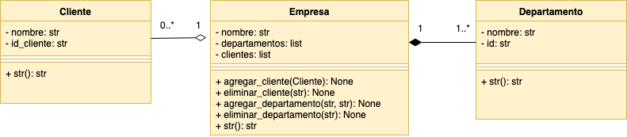

```python
from IPython.display import Image
Image(filename='./cardinalidad.png')
```

Otro ejemplo:

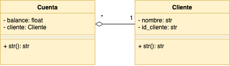

```python
from IPython.display import Image
Image(filename='./cardinalidad2.png')
```

```python
class Cuenta:
    def __init__(self, balance, cliente):
        self.__balance = balance
        self.__cliente = cliente
    def __str__(self):
        x = "%s Balance: %f" % (str(self.__cliente), self.__balance)
        return(x)

class Cliente:
    def __init__(self, nombre, id_cliente):
        self.__nombre = nombre
        self.__id_cliente = id_cliente
    @property
    def id_cliente(self):
        return(self.__id_cliente)
    def __str__(self):
        x = "%s (ID:%s)" % (self.__nombre, self.__id_cliente)
        return(x)
```

```python
c1 = Cliente("Juan", "12554")
x = Cuenta(5000, c1)
print(x)
```

```
Juan (ID:12554) Balance: 5000.000000
```

Las cardinalidades o multiplicidades pueden tomar los siguientes valores:

| Cardinalidad | Descripción |
| --- | --- |
| 1 | Sólo uno |
| 0..1 | Cero o uno |
| 0..* | Cero o muchos |
| * | Cero o muchos |
| 1..* | Uno o muchos |

## Clases Abstractas

Las clases abstractas son clases que no se pueden instanciar, es decir que no podemos crear una objeto de ese tipo, y todas las clases que hereden de esa clase abstracta tienen que implementar las mismas funciones de la clase abstracta.

Son muy útiles para crear patrones de clases, es decir clases que tienen que tener obligatoriamente los mismos métodos.

```python
from abc import  ABCMeta, abstractmethod

# Clase Abstracta, ABC Class
class Base(metaclass = ABCMeta):
    @abstractmethod
    def __str__(self):
        pass
    @abstractmethod
    def Captura(self):
        pass
```

# Polimorfismo

### Listas Polimórficas: Se caracteriza porque sus nodos pueden ser de diferente tipo.

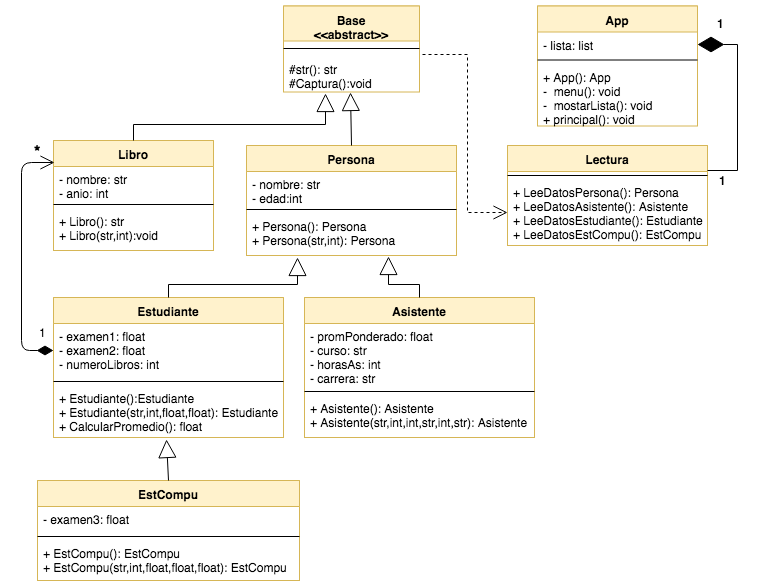

```python
from IPython.display import Image
Image(filename='./DisenoPersonas.png')
```

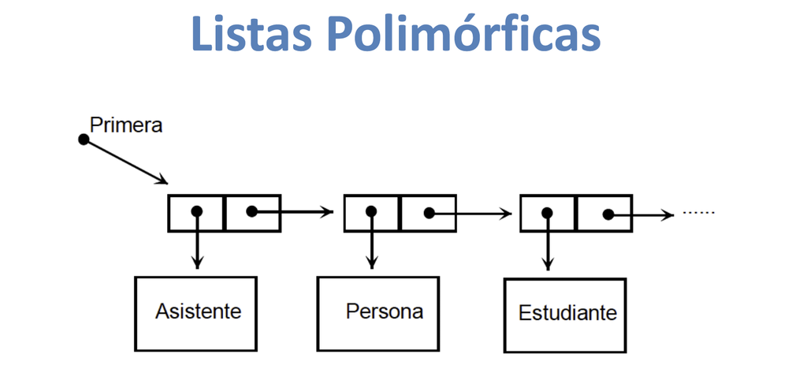

```python
from IPython.display import Image
Image(filename='./ListaPoli.png')
```

```python
from abc import  ABCMeta, abstractmethod

# Clase Abstracta, ABC Class
class Base(metaclass = ABCMeta):
    @abstractmethod
    def __str__(self):
        pass
    @abstractmethod
    def Captura(self):
        pass
```

```python
class Libro(Base):
    def __init__(self,nombre = "",anio = 0):
        self.__nombre = nombre
        self.__anio = anio
    @property
    def nombre(self):
        return self.__nombre
    @property
    def anio(self):
        return self.__anio
    @nombre.setter
    def nombre(self, nuevo_nombre):
        self.__nombre = nuevo_nombre
    @anio.setter
    def anio(self, nuevo_anio):
        self.__anio = nuevo_anio
    # Los siguientes métodos usan los set y get NO los atributos
    def __str__(self):
         return "Nombre del Libro: %s\nAño: %i" % (self.nombre, self.anio)
    def Captura(self):
        self.nombre = input("Nombre del Libro:")
        self.anio = int(input("Año del Libro:"))
```

```python
class Persona(Base):
    def __init__(self,nombre = "", edad = 0):
        self.__nombre = nombre
        self.__edad = edad
    @property
    def nombre(self):
        return self.__nombre
    @property
    def edad(self):
        return self.__edad
    @nombre.setter
    def nombre(self, nuevo_nombre):
        self.__nombre = nuevo_nombre
    @edad.setter
    def edad(self, nueva_edad):
        self.__edad = nueva_edad
    # Los siguientes métodos usan los set y get NO los atributos
    def __str__(self):
        return "Persona:%s\nEdad:%i" % (self.nombre,self.edad)
    def Captura(self):
        self.nombre = input("Digite el nombre: ")
        self.edad = int(input("Digite la edad:"))


class Asistente(Persona):
    def __init__(self,nombre="",edad=0,prom=0,cur="",hA=0,carr=""):
        Persona.__init__(self,nombre,edad)
        self.__promPonderado = prom
        self.__curso = cur
        self.__horasAs = hA
        self.__carrera = carr
    @property
    def promPonderado(self):
        return self.__promPonderado
    @property
    def curso(self):
        return self.__curso
    @property
    def horasAs(self):
        return self.__horasAs
    @property
    def carrera(self):
        return self.__carrera
    @promPonderado.setter
    def promPonderado(self, nuevo_promPonderado):
        self.__promPonderado = nuevo_promPonderado
    @curso.setter
    def curso(self, nuevo_curso):
        self.__curso = nuevo_curso
    @horasAs.setter
    def horasAs(self, nueva_horasAs):
        self.__horasAs = nueva_horasAs
    @carrera.setter
    def carrera(self, nueva_carrera):
        self.__carrera = nueva_carrera
    # Los siguientes métodos usan los set y get NO los atributos
    def __str__(self):
        s ="Asistente:%s\nEdad:%i\nCarrera:%s\nHoras Asignadas:%i\nCurso:%s\nPromedio Ponderado:%s"
        return s % (self.nombre,self.edad, self.carrera, self.horasAs,self.curso,self.promPonderado)
    def Captura(self):
        Persona.Captura(self)
        self.carrera = input("Digite la carrera: ")
        self.horasAs = int(input("Digite las horas asistente:"))
        self.curso = input("Digite el curso asignado:")
        self.promPonderado = int(input("Digite el promedio ponderado:"))

class Estudiante(Persona):
    def __init__(self,nombre="",edad=0,examen1=0,examen2=0):
        Persona.__init__(self,nombre,edad)
        self.__examen1 = examen1
        self.__examen2 = examen2
        self.__numeroLibros = 0
        self.__libros = []
    @property
    def examen1(self):
        return self.__examen1
    @property
    def examen2(self):
        return self.__examen2
    @property
    def numeroLibros(self):
        return self.__numeroLibros
    @property
    def libros(self):
        return self.__libros
    @examen1.setter
    def examen1(self, nuevo_examen1):
        self.__examen1 = nuevo_examen1
    @examen2.setter
    def examen2(self, nuevo_examen2):
        self.__examen2 = nuevo_examen2
    @numeroLibros.setter
    def numeroLibros(self, nuevo_numeroLibros):
        self.__numeroLibros = nuevo_numeroLibros
    @libros.setter
    def libros(self, nuevos_libros):
        self.__libros = nuevos_libros
    # Los siguientes métodos usan los set y get NO los atributos
    def calculaPromedio(self):
        return (self.examen1+self.examen2)/2
    def __str__(self):
        s ="Estudiante:%s\nPromedio:%i\n=====Libros====="
        for i in range(self.numeroLibros):
            s = s +"\n"+ str(self.libros[i])
        s = s + "\n================"
        return s % (self.nombre,self.calculaPromedio())
    def Captura(self):
        Persona.Captura(self)
        self.examen1 = int(input("Nota Examen 1:"))
        self.examen2 = int(input("Nota Examen 2:"))
        self.numeroLibros = int(input("Numero de libros del estudiante:"))
        for i in range(self.numeroLibros):
            lib = Libro()
            lib.Captura()
            self.libros.append(lib)

class EstCompu(Estudiante):
    def __init__(self,nombre="",edad=0,examen1=0,examen2=0,examen3=0):
        Estudiante.__init__(self,nombre,edad,examen1,examen2)
        self.__examen3 = examen3
    @property
    def examen3(self):
        return self.__examen3
    @examen3.setter
    def examen3(self, nuevo_examen3):
        self.__examen3 = nuevo_examen3
    # Los siguientes métodos usan los set y get NO los atributos
    def calculaPromedio(self):
        return (self.examen1+self.examen2+self.examen3)/3
    def __str__(self):
        s ="Estudiante Computación:%s\nPromedio:%i\n=====Libros====="
        for i in range(self.numeroLibros):
            s = s +"\n"+ str(self.libros[i])
        s = s + "\n================"
        return s % (self.nombre,self.calculaPromedio())
    def Captura(self):
        Persona.Captura(self)
        self.examen1 = int(input("Nota Examen 1:"))
        self.examen2 = int(input("Nota Examen 2:"))
        self.examen3 = int(input("Nota Examen 3:"))
        self.numeroLibros = int(input("Numero de libros del estudiante:"))
        for i in range(self.numeroLibros):
            lib = Libro()
            lib.Captura()
            self.libros.append(lib)
```

```python
import os

class Lectura:
    def LeeDatosPersona(self):
        persona = Persona()
        os.system('clear') #os.system('cls') #en windows
        persona.Captura()
        return persona
    def LeeDatosEstudiante(self):
        estudiante = Estudiante()
        os.system('clear') #os.system('cls') #en windows
        estudiante.Captura()
        return estudiante
    def LeeDatosEstCompu(self):
        estudianteC = EstCompu()
        os.system('clear') #os.system('cls') #en windows
        estudianteC.Captura()
        return estudianteC
    def LeeDatosAsistente(self):
        asistente = Asistente()
        os.system('clear') #os.system('cls') #en windows
        asistente.Captura()
        return asistente
```

```python
class App:
    def __init__(self):
        self.__lista = list()
        self.__lec = Lectura()
    def __menu(self):
        #os.system('clear') #os.system('cls') #en windows
        print(" ==================================================== ")
        print(" [1] Insertar Persona ")
        print(" [2] Insertar Asistente")
        print(" [3] Insertar Estudiante")
        print(" [4] Insertar Estudiante de Computación")
        print(" [5] Ver la Lista Polimórfica" )
        print(" [6] Borrar la Lista Polimórfica")
        print(" [7] Salir")
        print(" ==================================================== ")
        return input("> ")
    def __mostrarLista(self):
        for i in range(len(self.__lista)):
            print(self.__lista[i])
            print(15 * "*" + "\n")
    def principal(self):
        respuesta = ""
        while respuesta != "7":
            respuesta = self.__menu()
            if respuesta == "1":
                self.__lista.append(self.__lec.LeeDatosPersona())
            elif respuesta == "2":
                self.__lista.append(self.__lec.LeeDatosAsistente())
            elif respuesta == "3":
                self.__lista.append(self.__lec.LeeDatosEstudiante())
            elif respuesta == "4":
                self.__lista.append(self.__lec.LeeDatosEstCompu())
            elif respuesta == "5":
                self.__mostrarLista()
                input("Digite cualquier tecla para continuar")
            elif respuesta == "6":
                self.__lista.clear()

prueba = App()
prueba.principal()
```

```
 ====================================================
 [1] Insertar Persona
 [2] Insertar Asistente
 [3] Insertar Estudiante
 [4] Insertar Estudiante de Computación
 [5] Ver la Lista Polimórfica
 [6] Borrar la Lista Polimórfica
 [7] Salir
 ====================================================
> 2
Digite el nombre: Luis
Digite la edad:25
Digite la carrera: Matemática
Digite las horas asistente:12
Digite el curso asignado:Cálculo 2
Digite el promedio ponderado:95
 ====================================================
 [1] Insertar Persona
 [2] Insertar Asistente
 [3] Insertar Estudiante
 [4] Insertar Estudiante de Computación
 [5] Ver la Lista Polimórfica
 [6] Borrar la Lista Polimórfica
 [7] Salir
 ====================================================
> 1
Digite el nombre: María
Digite la edad:52
 ====================================================
 [1] Insertar Persona
 [2] Insertar Asistente
 [3] Insertar Estudiante
 [4] Insertar Estudiante de Computación
 [5] Ver la Lista Polimórfica
 [6] Borrar la Lista Polimórfica
 [7] Salir
 ====================================================
> 3
Digite el nombre: Alejandro
Digite la edad:24
```

[output cut: 61 more lines]

```
Año: 2021
================
***************

Digite cualquier tecla para continuar7
 ====================================================
 [1] Insertar Persona
 [2] Insertar Asistente
 [3] Insertar Estudiante
 [4] Insertar Estudiante de Computación
 [5] Ver la Lista Polimórfica
 [6] Borrar la Lista Polimórfica
 [7] Salir
 ====================================================
> 7
```

# Herencia Múltiple

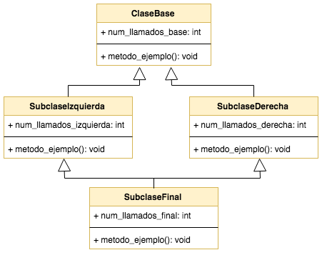

```python
from IPython.display import Image
Image(filename='./Herencia_Multiple.png')
```

### Forma incorrecta de programarlo

```python
class ClaseBase:
    num_llamados_base = 0
    def metodo_ejemplo(self):
        print("Llamando metodo_ejemplo en clase Base")
        self.num_llamados_base += 1

class SubclaseIzquierda(ClaseBase):
    num_llamados_izquierda = 0
    def metodo_ejemplo(self):
        ClaseBase.metodo_ejemplo(self)
        print("Llamando metodo_ejemplo en SubclaseIzquierda desde SubclaseFinal")
        self.num_llamados_izquierda += 1

class SubclaseDerecha(ClaseBase):
    num_llamados_derecha = 0
    def metodo_ejemplo(self):
        ClaseBase.metodo_ejemplo(self)
        print("Llamando metodo_ejemplo en SubclaseDerecha desde SubclaseFinal")
        self.num_llamados_derecha += 1

class SubclaseFinal(SubclaseIzquierda, SubclaseDerecha):
    num_llamados_final = 0
    def metodo_ejemplo(self):
        SubclaseIzquierda.metodo_ejemplo(self)
        SubclaseDerecha.metodo_ejemplo(self)
        print("Llamando metodo_ejemplo desde SubclaseFinal")
        self.num_llamados_final += 1

s = SubclaseFinal()
s.metodo_ejemplo()
print(s.num_llamados_final,s.num_llamados_izquierda,s.num_llamados_derecha,s.num_llamados_base)
```

```
Llamando metodo_ejemplo en clase Base
Llamando metodo_ejemplo en SubclaseIzquierda desde SubclaseFinal
Llamando metodo_ejemplo en clase Base
Llamando metodo_ejemplo en SubclaseDerecha desde SubclaseFinal
Llamando metodo_ejemplo desde SubclaseFinal
1 1 1 2
```

### Forma correcta de programarlo

```python
# Ejemplo Herencia Múltiple - Versión 2 - Forma correcta de hacerlo

class ClaseBase:
    num_llamados_base = 0
    def metodo_ejemplo(self):
        print("Llamando metodo_ejemplo en la clase Base")
        self.num_llamados_base += 1

class SubclaseIzquierda(ClaseBase):
    num_llamados_izquierda = 0
    def metodo_ejemplo(self):
        super().metodo_ejemplo()
        print("Llamando metodo_ejemplo en Izquierda SubclaseFinal")
        self.num_llamados_izquierda += 1

class SubclaseDerecha(ClaseBase):
    num_llamados_derecha = 0
    def metodo_ejemplo(self):
        super().metodo_ejemplo()
        print("Llamando metodo_ejemplo en Derecha SubclaseFinal")
        self.num_llamados_derecha += 1

class SubclaseFinal(SubclaseIzquierda, SubclaseDerecha):
    num_llamados_final = 0
    def metodo_ejemplo(self):
        super().metodo_ejemplo()
        print("Llamando metodo_ejemplo en SubclaseFinal")
        self.num_llamados_final += 1

s = SubclaseFinal()
s.metodo_ejemplo()
print(s.num_llamados_final,s.num_llamados_izquierda,s.num_llamados_derecha,s.num_llamados_base)
```

```
Llamando metodo_ejemplo en la clase Base
Llamando metodo_ejemplo en Derecha SubclaseFinal
Llamando metodo_ejemplo en Izquierda SubclaseFinal
Llamando metodo_ejemplo en SubclaseFinal
1 1 1 1
```

[figure not shown]

```python
from IPython.display import Image
Image(filename='./logo_python.png')
```